# HW 7

Bingying Liu

April 8, 2020

## Question 1:

#### Part(a): Using the g-prior with g = n = 6, generate samples/realizations from the prior predictive distribution for a single swimmer over the 12 weeks (W=2,4,6,8,10,12) and create a density plot of the predictive draws (one for each W). Are the values plausible?

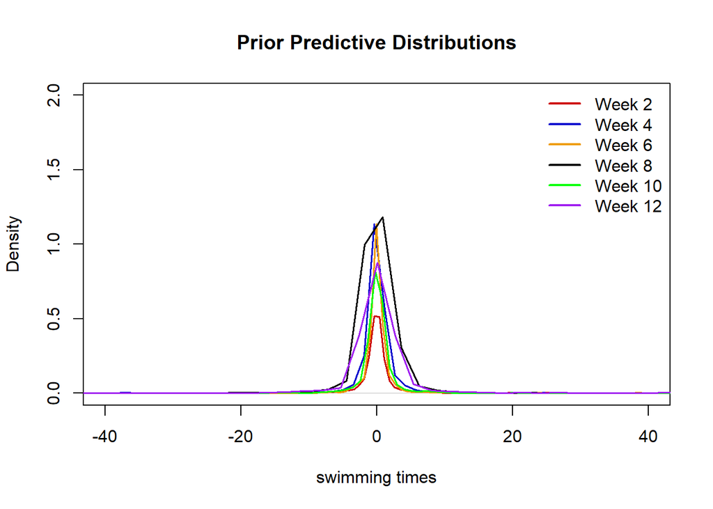

```r
Y <- read.table("http://www2.stat.duke.edu/~pdh10/FCBS/Exercises/swim.dat")
Y <- t(Y)

# data summaries
n = nrow(Y)
n_swimmers = ncol(Y)
g = n
W = seq(2,12,length.out=n)
X = cbind(rep(1,n),(W-mean(W)))
p = ncol(X)

# Hyperparameters for the prior
nu_0 = 1
sigma_0_sq = 1/10
beta_0 = c(0,0)


n_iter = 1000
prior_predict = matrix(0, nrow=n_iter, ncol=nrow(X))
for (i in 1:n_iter){
  # Prior predictive distribution
  SIGMA_SQ = 1/rgamma(1,nu_0/2,nu_0*sigma_0_sq/2)
  Sigma_0 = g*SIGMA_SQ*solve(t(X)%*%X)
  BETA = rmvnorm(1, beta_0, Sigma_0)
  prior_predict[i,] = rmvnorm(1, X%*%t(BETA), SIGMA_SQ*diag(1,nrow=n)) # save different weeks
}

colnames(prior_predict) = c('Week 2','Week 4','Week 6','Week 8','Week 10','Week 12')

plot(density(prior_predict[,'Week 2']),col="red3",xlim=c(-40,40),ylim=c(0,2),lwd=1.5,
             main="Prior Predictive Distributions",xlab="swimming times")
legend("topright",2,c('Week 2','Week 4','Week 6','Week 8','Week 10','Week 12'),col=c("red3","blue3","orange2","black","green","purple"),lwd=2,bty="n")
lines(density(prior_predict[,"Week 4"]),col="blue3",lwd=1.5)
lines(density(prior_predict[,"Week 6"]),col="orange2",lwd=1.5)
lines(density(prior_predict[,"Week 8"]),col="black",lwd=1.5)
lines(density(prior_predict[,"Week 10"]),col="green",lwd=1.5)
lines(density(prior_predict[,"Week 12"]),col="purple",lwd=1.5)
```

Yes, the values are plausible because since we’re using a g prior, the prior predictive distribution all center around 0.

#### Part(b): Using the data, and the g-prior with g = n = 6 for each swimmer, give the posterior distributions of $\beta_0$, $\beta_1$ and $\sigma^2$ for each swimmer.

```r
# set number of iterations
S <- 10000
BETA = array(0,c(n_swimmers, S, p))
SIGMA_SQ = matrix(0,n_swimmers,S)

# Gibbs sampler
for (j in 1:n_swimmers){
  beta_ols <- solve(t(X)%*%X)%*%t(X)%*%Y[,j]

  # sample sigma_sq
  nu_n <- nu_0 + n
  Hg <- (g/(g+1))* X%*%solve(t(X)%*%X)%*%t(X)
  SSRg <- t(Y[,j])%*%(diag(1,nrow=n) - Hg)%*%Y[,j]
  nu_n_sigma_n_sq <- nu_0*sigma_0_sq + SSRg
  sigma_sq <- 1/rgamma(S,(nu_n/2),(nu_n_sigma_n_sq/2))

  # sample beta
  mu_n <- g*beta_ols/(g+1)
  beta <- matrix(nrow=S,ncol=p)
  for(s in 1:S){
    Sigma_n <- g*sigma_sq[s]*solve(t(X)%*%X)/(g+1)
    beta[s,] <- rmvnorm(1,mu_n,Sigma_n)
  }

  BETA[j,,] = beta
  SIGMA_SQ[j,] = sigma_sq

}

# posterior summaries: means
beta_postmean <- t(apply(BETA,c(1,3),mean))
colnames(beta_postmean) <- c("Swimmer 1","Swimmer 2","Swimmer 3","Swimmer 4")
rownames(beta_postmean) <- c("beta_0","beta_1")
beta_postmean
```

```
##          Swimmer 1   Swimmer 2   Swimmer 3   Swimmer 4
## beta_0 19.67429187 20.01411681 19.43440000 20.18126890
## beta_1 -0.04774097  0.01953296  0.01719867 -0.03140066
```

#### Part(c): For each swimmer j, plot their posterior predictive distributions for a future time T^* two weeks after the last recorded observation (overlay the 4 densities in a single plot).

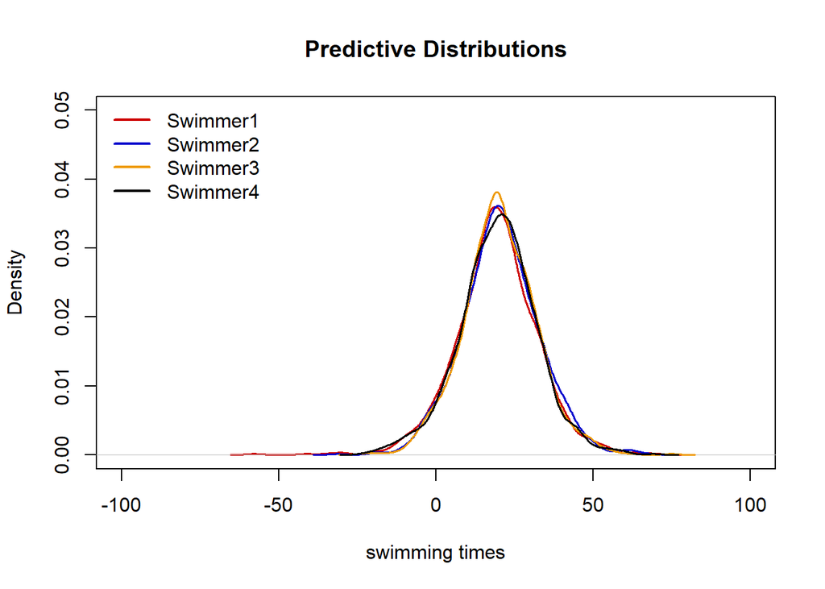

```r
x_new <- matrix(c(1,(14-mean(W))),ncol=1)
post_pred <- matrix(0,nrow=n_iter,ncol=n_swimmers)
for(j in 1:n_swimmers){
  post_pred[,j] <- rnorm(n_iter,BETA[j,,]%*%x_new,sqrt(SIGMA_SQ[j,]))
}
colnames(post_pred) <- c("Swimmer 1","Swimmer 2","Swimmer 3","Swimmer 4")

plot(density(post_pred[,"Swimmer 1"]),col="red3",xlim=c(-100,100),ylim=c(0,0.05),lwd=1.5,
     main="Predictive Distributions",xlab="swimming times")
legend("topleft",2,c("Swimmer1","Swimmer2","Swimmer3","Swimmer4"),col=c("red3","blue3","orange2","black"),lwd=2,bty="n")
lines(density(post_pred[,"Swimmer 2"]),col="blue3",lwd=1.5)
lines(density(post_pred[,"Swimmer 3"]),col="orange2",lwd=1.5)
lines(density(post_pred[,"Swimmer 4"]),lwd=1.5)
```

#### Part(d): The coach of the team has to recommend which of the swimmers to compete in a swim meet in two weeks time. Using draws from the predictive distributions, compute $P(Y_j^*=max(Y_1^*,Y_2^*,Y_3^*,Y_4^*))$ for each swimmer $j$, and based on this make a recommendation to the coach.

```r
post_pred_min <- as.data.frame(apply(post_pred,1,function(x) which(x==max(x))))
colnames(post_pred_min) <- "Swimmers"
post_pred_min$Swimmers <- as.factor(post_pred_min$Swimmers)
levels(post_pred_min$Swimmers) <- c("Swimmer 1","Swimmer 2","Swimmer 3","Swimmer 4")
table(post_pred_min$Swimmers)/n_iter
```

```
##
## Swimmer 1 Swimmer 2 Swimmer 3 Swimmer 4
##     0.237     0.269     0.255     0.239
```

I recommend swimmer 1 to the coach since the maximum swimming time for swimmer 1 is lowest among all four swimmers.

## Hoff 9.2: Model selection

#### Part(a): Fit a regression model using the g-prior with $g=n$, $\nu_0=2$ and $\sigma_0^2=1$. Obtain thee posteror confidence intervals for all of the parameters.

```r
az = read.table("azdiabetes.dat.txt", header = TRUE)[,-8]

# glu ~ 1 + npreg + bp + skin + bmi + ped + age
### data and priors
n = nrow(az)
intercept = as.matrix(rep(1, n), ncol = 1)
colnames(intercept) = c("intercept")
rownames(intercept) = 1:nrow(az)
X = cbind(intercept, as.matrix(az[, -2])) #delete glu col
Y = as.matrix(az[, 2], ncol = 1)
p = ncol(X)
nu_0 = 2
sigma_0_sq = 1
g = n


# Hyperparameters for the prior
beta_ols = solve(t(X)%*%X)%*%t(X)%*%Y

# MC sampling
S = 10000

# sample sigma_sq
nu_n <- nu_0 + n
Hg <- (g/(g+1))* X%*%solve(t(X)%*%X)%*%t(X)
SSRg <- t(Y)%*%(diag(1,nrow=n) - Hg)%*%Y
nu_n_sigma_n_sq <- nu_0*sigma_0_sq + SSRg
sigma_sq <- 1/rgamma(S,(nu_n/2),(nu_n_sigma_n_sq/2))

# sample beta
mu_n <- g*beta_ols/(g+1)
beta <- matrix(nrow=S,ncol=p)
for(s in 1:S){
  Sigma_n <- g*sigma_sq[s]*solve(t(X)%*%X)/(g+1)
  beta[s,] <- rmvnorm(1,mu_n,Sigma_n)
}

# posterior summaries
colnames(beta) <- colnames(X)
mean_beta <- apply(beta,2,mean)
round(mean_beta,4)
```

```
## intercept     npreg        bp      skin       bmi       ped       age
##   52.1656   -0.6509    0.2043    0.1906    0.6480   10.4850    0.7645
```

```r
round(apply(beta,2,function(x) quantile(x,c(0.025,0.975))),4)
```

```
##       intercept   npreg      bp    skin    bmi     ped    age
## 2.5%     35.127 -1.6288 -0.0168 -0.1189 0.1520  3.3186 0.4546
## 97.5%    69.233  0.3238  0.4271  0.5021 1.1441 17.6413 1.0753
```

```r
sigma_sq_mx <- as.matrix(sigma_sq,nrow=S)
colnames(sigma_sq_mx) <- 'sigma^2'
apply(sigma_sq_mx, 2, function(x) quantile(x,c(0.025,0.975)))
```

```
##        sigma^2
## 2.5%  745.8955
## 97.5% 948.3742
```

#### Part(b): Perform the model selection and averaging procedure described in Section 9.3. Obtain $Pr(\beta_j \neq 0|y)$, as well as posterior confidence intervals for all of the parameters. Compare to the results in part a).

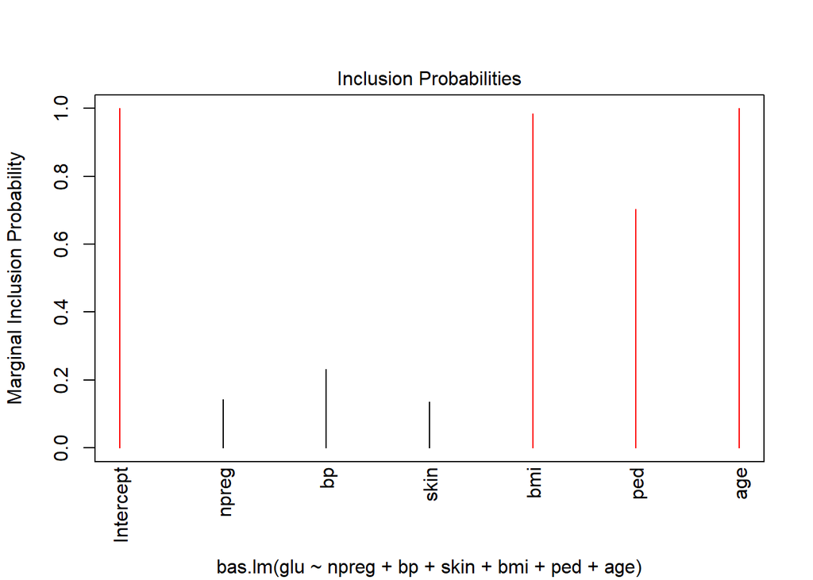

```r
Data_bas <- bas.lm(glu~npreg+bp+skin+bmi+ped+age, data=az, prior="g-prior",alpha=n,
                   n.models=2^p, update=50, initprobs="Uniform")
plot(Data_bas,which=4)
```

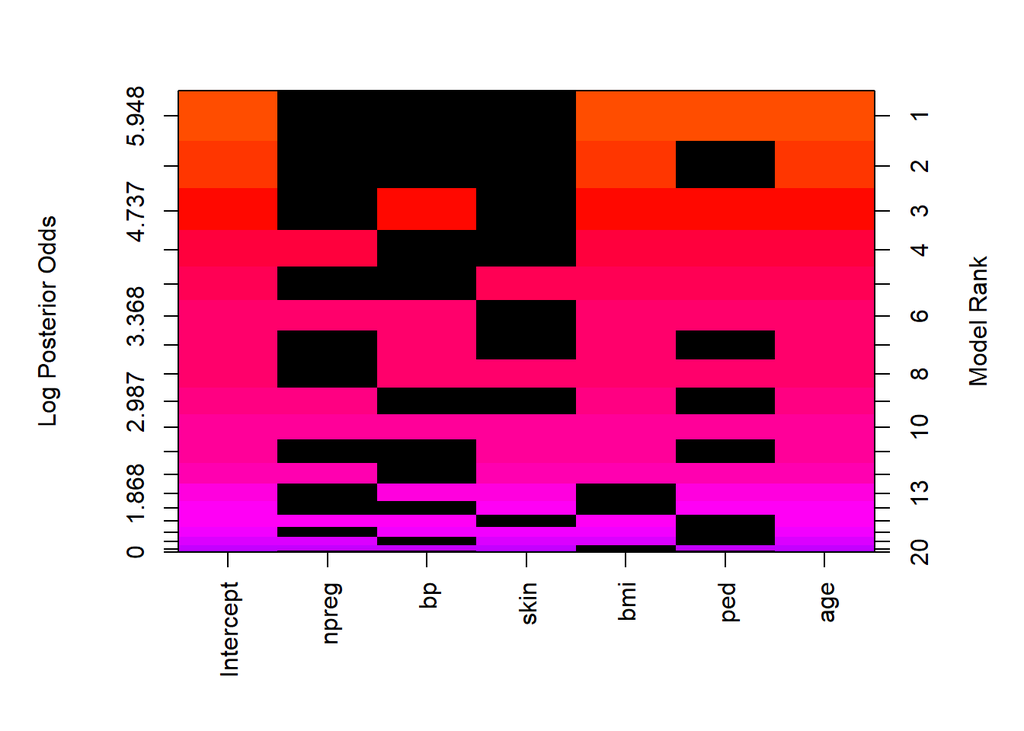

```r
image(Data_bas)
```

```r
coef(Data_bas)  # Pr(Beta_j != 0)
```

```
##
##  Marginal Posterior Summaries of Coefficients:
##
##  Using  BMA
##
##  Based on the top  64 models
##            post mean  post SD    post p(B != 0)
## Intercept  121.03008    1.24993    1.00000
## npreg       -0.09522    0.29819    0.14362
## bp           0.04758    0.10266    0.23233
## skin         0.02998    0.10059    0.13595
## bmi          0.90862    0.24219    0.98400
## ped          7.38061    5.69703    0.70388
## age          0.73746    0.13594    0.99999
```

```r
confint(coef(Data_bas))  # posterior confidence intervals
```

```
##                    2.5%       97.5%         beta
## Intercept 118.563948735 123.4272764 121.03007519
## npreg      -0.975241884   0.0000000  -0.09522102
## bp          0.000000000   0.3045498   0.04757862
## skin       -0.001206578   0.3204308   0.02997921
## bmi         0.457790777   1.3744172   0.90861759
## ped         0.000000000  15.9225798   7.38061463
## age         0.464670284   0.9942756   0.73746007
## attr(,"Probability")
## [1] 0.95
## attr(,"class")
## [1] "confint.bas"
```